# Project course "Introduction to Data Analysis"

## Do we still need gyms?

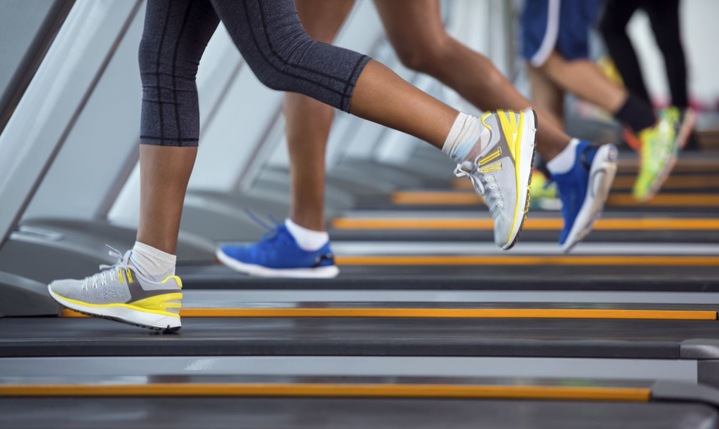

### Dataset description and variables:

A sample of 1000 people was tested with three new medicines to improve physical features

### Variables:

Gender: Binary (M-F) Age: Age of people (numeric) Km Before: Running Kilometers before taking any medicine (Km) Kg Before: Weight of people before taking any medicine (Kg) Time Before: Running time before taking any medicine (Minutes) Medicine 1: Binary (Yes-No) Medicine 2: Binary (Yes-No) Medicine 3: Binary (Yes-No) Km After: Running Kilometers after taking any medicine (Km) Kg After: Weight of people after taking any medicine (Kg) Time After: Running time after taking any medicine (Minutes) SideEffects: Binary (Y-N)

### Dataset link :

https://www.kaggle.com/datasets/saralattarulo/do-we-still-need-gyms

### We need some packages to download

```r
#Install packages —————————————————-
install.packages("RCurl")
install.packages("Hmisc")
install.packages("RColorBrewer")
install.packages("ggplot2")
install.packages("ggcorrplot")
install.packages("corrplot")
install.packages("ggcorrplot")
```

[output not shown]

[output not shown]

[output not shown]

[output not shown]

[output not shown]

[output not shown]

[output not shown]

### We requisition the libraries so that we can use the functions :

```r
#libraries ————————————————————–
library(skimr)
library(Hmisc)
library(RColorBrewer)
library(ggplot2)
library(dplyr)
library(ggcorrplot)
library(corrplot)
library(ggcorrplot)
```

### Import the data :

```r
#set the working directory
setwd("C:/Users/dell/Desktop/دورة R 2022/مشروع دورة الR")
# Reading data and call it "df"
df <- read.csv("survey.csv.csv",sep = ";")
```

## Discovering the dataset:

### Dimensions :

```r
# Know the dimensions of the data (row, column)
dim(df)
```

1. 1000

2. 12

### look at the first and last six rows:

```r
# Get the first sex rows
head(df)
```

A data.frame: 6 × 12

|  | Gender <fct> | Age <int> | KmBefore <dbl> | KgBefore <dbl> | TimeBefore <dbl> | Medicine1 <fct> | Medicine2 <fct> | Medicine3 <fct> | KmAfter <dbl> | KgAfter <dbl> | TimeAfter <dbl> | SideEffects <fct> |
| --- | --- | --- | --- | --- | --- | --- | --- | --- | --- | --- | --- | --- |
| 1 | F | 32 | 4.06 | 74.7 | 41.2 | No | No | No | 4.37 | 91.8 | 61.1 | N |
| 2 | M | 37 | 3.96 | 76.3 | 43.9 | Yes | Yes | No | 3.09 | 89.6 | 69.7 | N |
| 3 | M | 43 | 3.80 | 91.7 | 47.9 | Yes | No | No | 6.26 | 92.7 | 49.8 | N |
| 4 | F | 26 | 5.17 | 75.4 | 59.6 | No | No | No | 5.81 | 89.1 | 60.9 | N |
| 5 | F | 36 | 3.72 | 77.0 | 54.9 | No | Yes | Yes | 7.80 | 91.7 | 60.7 | Y |
| 6 | M | 37 | 5.31 | 93.9 | 50.6 | No | Yes | Yes | 5.67 | 87.8 | 67.9 | N |

```r
# Get the last sex rows
tail(df)
```

A data.frame: 6 × 12

|  | Gender <fct> | Age <int> | KmBefore <dbl> | KgBefore <dbl> | TimeBefore <dbl> | Medicine1 <fct> | Medicine2 <fct> | Medicine3 <fct> | KmAfter <dbl> | KgAfter <dbl> | TimeAfter <dbl> | SideEffects <fct> |
| --- | --- | --- | --- | --- | --- | --- | --- | --- | --- | --- | --- | --- |
| 995 | M | 36 | 4.46 | 69.7 | 28.7 | Yes | No | Yes | 3.28 | 88.2 | 61.8 | N |
| 996 | M | 39 | 5.69 | 77.5 | 39.3 | No | No | Yes | 5.41 | 85.8 | 61.0 | Y |
| 997 | F | 35 | 4.57 | 93.2 | 50.2 | Yes | Yes | No | 5.86 | 96.6 | 64.4 | N |
| 998 | F | 36 | 2.72 | 72.3 | 53.8 | No | Yes | No | 2.63 | 92.8 | 68.9 | Y |
| 999 | M | 32 | 3.92 | 98.7 | 56.2 | No | Yes | No | 6.31 | 86.0 | 62.3 | N |
| 1000 | M | 32 | 3.85 | 79.3 | 52.6 | No | Yes | Yes | 5.21 | 89.1 | 64.4 | N |

### Column Names:

used to rename and replace the column names of the data frame in R.

```r
#Column Names: to check if it is need modification :
colnames(df)
```

1. 'Gender'

2. 'Age'

3. 'KmBefore'

4. 'KgBefore'

5. 'TimeBefore'

6. 'Medicine1'

7. 'Medicine2'

8. 'Medicine3'

9. 'KmAfter'

10. 'KgAfter'

11. 'TimeAfter'

12. 'SideEffects'

### Modify values name

The gsub() function in R can be used to replace all occurrences of certain text within a string in R.

```r
#modify values name in the Gender column (F to Female ,M to male):
df$Gender = gsub("F","Female",df$Gender)
df$Gender = gsub("M","Male",df$Gender)
```

```r
#modify values name in the SideEffects column (N to NO ,Y to Yes):
df$SideEffects = gsub("Y","Yes",df$SideEffects)
df$SideEffects = gsub("N","No",df$SideEffects)
```

### Check if a data contains null value and if there is duplicate in DataFrame :

```r
#checks if any of columns in the data have null values - should print False :
any((is.na(df)))
```

FALSE

```r
#print number of duplicates in the data :
sum(duplicated(df))
```

0

### Description :

skim() is an alternative to summary(),quickly providing a broad overview of a data frame.

```r
#discovering the dataset more (type of variables and some statistic measures)
skim(df)
```

```
-- Data Summary ------------------------
                           Values
Name                       df
Number of rows             1000
Number of columns          12
_______________________
Column type frequency:
  character                2
  factor                   3
  numeric                  7
________________________
Group variables            None

-- Variable type: character ----------------------------------------------------
# A tibble: 2 x 8
  skim_variable n_missing complete_rate   min   max empty n_unique whitespace
* <chr>             <int>         <dbl> <int> <int> <int>    <int>      <int>
1 Gender                0             1     4     6     0        2          0
2 SideEffects           0             1     2     3     0        2          0

-- Variable type: factor -------------------------------------------------------
# A tibble: 3 x 6
  skim_variable n_missing complete_rate ordered n_unique top_counts
* <chr>             <int>         <dbl> <lgl>      <int> <chr>
1 Medicine1             0             1 FALSE          2 No: 732, Yes: 268
2 Medicine2             0             1 FALSE          2 Yes: 622, No: 378
3 Medicine3             0             1 FALSE          2 No: 551, Yes: 449

-- Variable type: numeric ------------------------------------------------------
# A tibble: 7 x 11
  skim_variable n_missing complete_rate  mean    sd    p0   p25   p50   p75
* <chr>             <int>         <dbl> <dbl> <dbl> <dbl> <dbl> <dbl> <dbl>
1 Age                   0             1 34.8  5.01  19    31    35    38
2 KmBefore              0             1  4.02 0.774  1.72  3.5   4.01  4.57
3 KgBefore              0             1 80.6  9.30  51.6  74.5  80.7  86.7
4 TimeBefore            0             1 44.9  9.99   8    38.3  44.6  51.6
5 KmAfter               0             1  5.00 1.46   0.51  3.96  5.01  5.97
6 KgAfter               0             1 90.1  2.95  81.3  88.2  90.1  92.1
7 TimeAfter             0             1 59.8  5.03  42.7  56.3  59.9  63
    p100 hist
*  <dbl> <chr>
1  50    ▁▅▇▅▁
2   6.28 ▁▅▇▅▁
3 109.   ▁▃▇▅▁
4  74.2  ▁▂▇▆▁
5  10.4  ▁▆▇▃▁
6  99.5  ▁▅▇▃▁
7  76.3  ▁▃▇▃▁
```

```r
#and by - Statistic Measures:
describe(df)
```

```
df

 12  Variables      1000  Observations
--------------------------------------------------------------------------------
Gender
       n  missing distinct
    1000        0        2

Value      Female   Male
Frequency     447    553
Proportion  0.447  0.553
--------------------------------------------------------------------------------
Age
       n  missing distinct     Info     Mean      Gmd      .05      .10
    1000        0       31    0.996    34.79    5.674       27       28
     .25      .50      .75      .90      .95
      31       35       38       41       43

lowest : 19 20 21 23 24, highest: 46 47 48 49 50
--------------------------------------------------------------------------------
KmBefore
       n  missing distinct     Info     Mean      Gmd      .05      .10
    1000        0      312        1    4.021   0.8764    2.710    3.030
     .25      .50      .75      .90      .95
   3.500    4.015    4.570    5.011    5.290

lowest : 1.72 1.85 1.97 1.99 2.00, highest: 5.94 5.95 6.12 6.27 6.28
--------------------------------------------------------------------------------
KgBefore
       n  missing distinct     Info     Mean      Gmd      .05      .10
    1000        0      358        1    80.57    10.48    64.70    68.60
     .25      .50      .75      .90      .95
   74.50    80.70    86.73    92.30    95.20

lowest :  51.6  54.6  55.3  56.0  56.1, highest: 105.1 106.4 107.0 107.3 109.2
--------------------------------------------------------------------------------
TimeBefore
       n  missing distinct     Info     Mean      Gmd      .05      .10
    1000        0      382        1    44.87    11.29    28.60    32.09
     .25      .50      .75      .90      .95
```

[output cut: 45 more lines]

```
       n  missing distinct     Info     Mean      Gmd      .05      .10
    1000        0      227        1    59.76    5.676    51.40    53.40
     .25      .50      .75      .90      .95
   56.27    59.90    63.00    66.11    68.10

lowest : 42.7 42.8 43.3 45.9 46.6, highest: 73.1 73.2 74.2 74.5 76.3
--------------------------------------------------------------------------------
SideEffects
       n  missing distinct
    1000        0        2

Value         No   Yes
Frequency    817   183
Proportion 0.817 0.183
--------------------------------------------------------------------------------
```

# Data analysis :

Now the data has been checked, and the data is ready for analysis

### Knowing the numbers of men and women in the study :

```r
#The dataset contains numbers of people by gender :
df_Gender<-df%>%
  group_by(Gender)%>%
  summarize(number_of_people= n())
df_Gender
```

A tibble: 2 × 2

| Gender <chr> | number_of_people <int> |
| --- | --- |
| Female | 447 |
| Male | 553 |

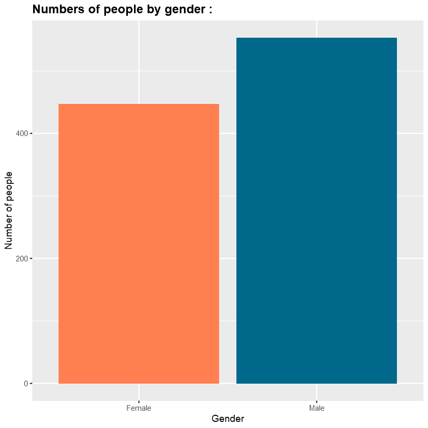

```r
#Basic barplot for Gender :
ggplot(data=df_Gender, aes(x=Gender, y=number_of_people)) +
  geom_bar(stat="identity",fill=c("coral","deepskyblue4"))+
  labs(y = "Number of people")+
  ggtitle("Numbers of people by gender :")+
  theme(plot.title = element_text(face="bold", size=14))
```

### Type of Medicines by Gender:

## Which of the three medicines is most used according to gender?

```r
#Number of people using each of three types of medication by gender:
#Medicine1 with other Medicine
counts1 <- table(df$Gender, df$Medicine1)
#Medicine2 with other Medicine
counts2 <- table(df$Gender, df$Medicine2)
#Medicine3 with other Medicine
counts3 <- table(df$Gender, df$Medicine3)
```

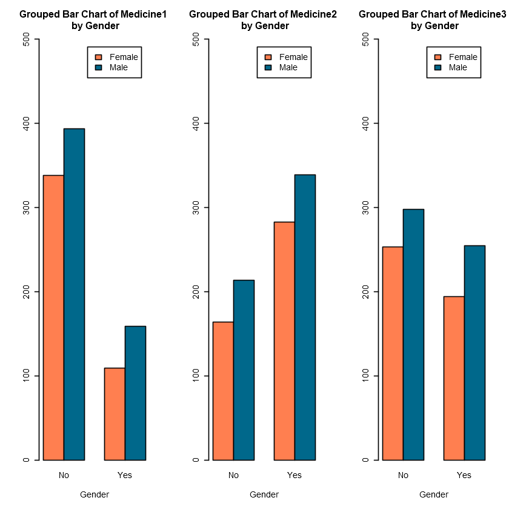

```r
# create grouped bar chart
## Create a 1 x 3 plotting matrix
par(mfrow=c(1,3))
#Medicine1 with other Medicine:
barplot(counts1, main="Grouped Bar Chart of Medicine1 \n by Gender",
        xlab="Gender", legend = T,ylim = c(0,500),col=c("coral","deepskyblue4"), beside=TRUE)
#Medicine2 with other Medicine:
barplot(counts2, main="Grouped Bar Chart of Medicine2 \n by Gender",
        xlab="Gender", legend = T,ylim = c(0,500),col=c("coral","deepskyblue4"), beside=TRUE)
#Medicine3 with other Medicine:
barplot(counts3, main="Grouped Bar Chart of Medicine3 \n by Gender",
        xlab="Gender", legend = T,ylim = c(0,500),col=c("coral","deepskyblue4"), beside=TRUE)
```

I noticed that medicine 2 is more used, I can't reveal the reason, is it the morest selling or the cheapest or is the effect useful in losing weight, I will try during the analysis of the data to reveal that if I can .

## Which of the three medicines has the most Side Effects?

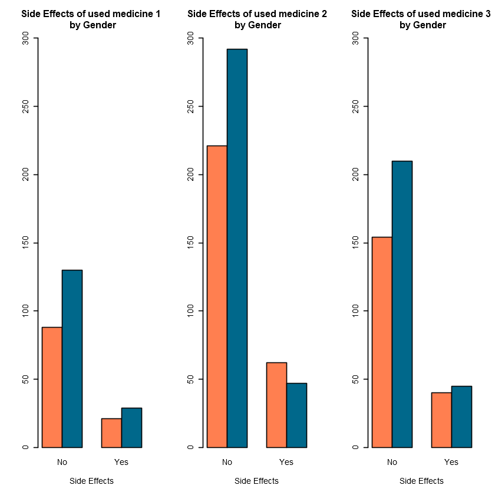

```r
#Type of Medicines by Side Effects:
#Number of people using each of three types of medication by Side Effects:
df1<-df %>%
  filter(df$Medicine1 == "Yes")%>%
  select(-c(Age,KmBefore,KgBefore,TimeBefore,KmAfter,KgAfter,TimeAfter,Medicine2,Medicine3))


df2<-df %>%
    filter(df$Medicine2 == "Yes")%>%
    select(-c(Age,KmBefore,KgBefore,TimeBefore,KmAfter,KgAfter,TimeAfter,Medicine1,Medicine3))

df3<-df %>%
  filter(df$Medicine3 == "Yes")%>%
  select(-c(Age,KmBefore,KgBefore,TimeBefore,KmAfter,KgAfter,TimeAfter,Medicine1,Medicine2))

## Create a 1 x 3 plotting matrix
par(mfrow=c(1,3))

barplot(table(df1$Gender,df1$SideEffects),main="Side Effects of used medicine 1 \n by Gender",
          xlab="Side Effects",ylim = c(0,300),col=c("coral","deepskyblue4"), beside=TRUE)

barplot(table(df2$Gender,df2$SideEffects),main="Side Effects of used medicine 2\n by Gender",
          xlab="Side Effects",ylim = c(0,300),col=c("coral","deepskyblue4"), beside=TRUE)


barplot(table(df3$Gender,df3$SideEffects),main="Side Effects of used medicine 3 \n by Gender",
        xlab="Side Effects",ylim = c(0,300),col=c("coral","deepskyblue4"), beside=TRUE)
```

So now my focus will be on Medicine 2 because it's the most common

## Medicine2

```r
#I focused on the second  Medicine 2 because it is the most used from male and female:

#create of new data that contain: people whose used Medicine 1 with Medicine 2 just
df_M1_M2<- df %>%
  filter(df$Medicine1 == "Yes",df$Medicine2 == "Yes",df$Medicine3 == "No")%>%
  select(-c(Age,KmBefore,KgBefore,TimeBefore,KmAfter,KgAfter,TimeAfter))

#create of new data that contain Medicine : people whose used Medicine 2 with Medicine 3 just
df_M2_M3<- df %>%
  filter(df$Medicine1 == "No",df$Medicine2 == "Yes",df$Medicine3 == "Yes")%>%
  select(-c(Age,KmBefore,KgBefore,TimeBefore,KmAfter,KgAfter,TimeAfter))

#create of new data that contain Medicine :people whose used Medicine 1, Medicine2 and Medicine 3
df_M1_M2_M3<- df %>%
  filter(df$Medicine1 == "Yes",df$Medicine2 == "Yes",df$Medicine3 == "Yes")%>%
  select(-c(Age,KmBefore,KgBefore,TimeBefore,KmAfter,KgAfter,TimeAfter))

#create of new data that contain Medicine : people whose used Medicine 2 just
df_M2<- df %>%
  filter(df$Medicine1 == "No",df$Medicine2 == "Yes",df$Medicine3 == "No")%>%
  select(-c(Age,KmBefore,KgBefore,TimeBefore,KmAfter,KgAfter,TimeAfter))
```

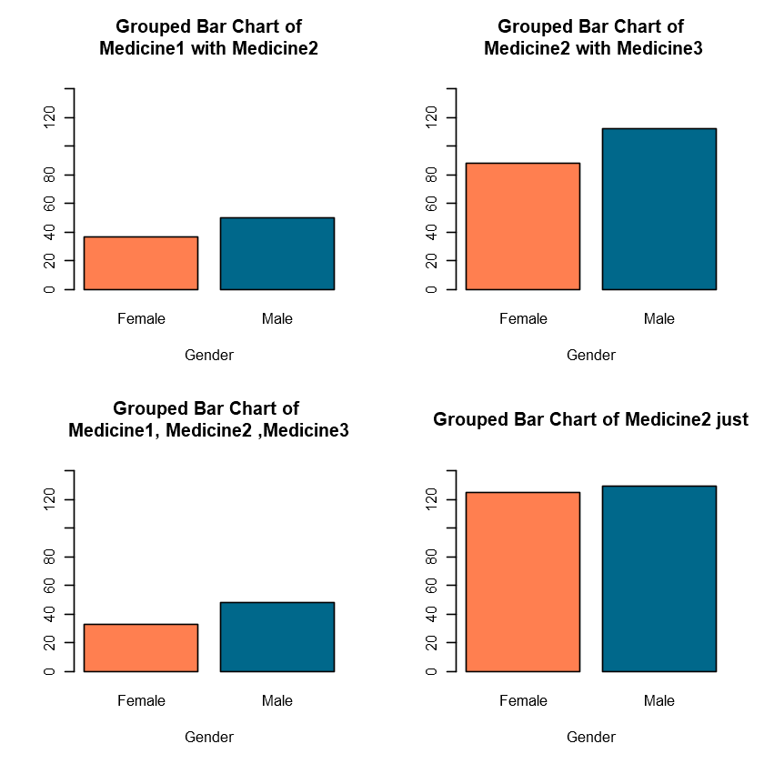

```r
## Create a 2 x 2 plotting matrix
par(mfrow=c(2,2))

#Now , determine which of the people who use medicine 2 highest
barplot(table(df_M1_M2$Gender),main="Grouped Bar Chart of\n Medicine1 with Medicine2 ",
        xlab="Gender",ylim = c(0,150),col=c("coral","deepskyblue4"), beside=TRUE)

barplot(table(df_M2_M3$Gender),main="Grouped Bar Chart of\n Medicine2 with Medicine3",
        xlab="Gender",ylim = c(0,150),col=c("coral","deepskyblue4"), beside=TRUE)

barplot(table(df_M1_M2_M3$Gender),main="Grouped Bar Chart of \n Medicine1, Medicine2 ,Medicine3 ",
        xlab="Gender",ylim = c(0,150),col=c("coral","deepskyblue4"), beside=TRUE)

barplot(table(df_M2$Gender),main="Grouped Bar Chart of Medicine2 just",
        xlab="Gender",ylim = c(0,150),col=c("coral","deepskyblue4"), beside=TRUE)
```

## table for SideEffects with Medicine 2

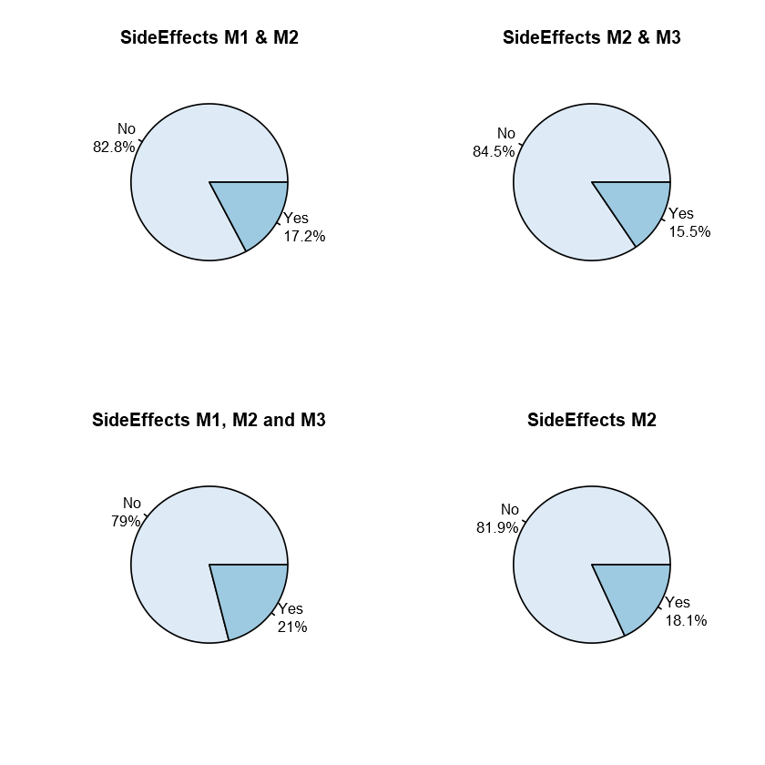

```r
## Create a 2 x 2 plotting matrix
par(mfrow=c(2,2))

# table for SideEffects : people whose used Medicine 1 with Medicine 2 just
fs_M1_M2 <- table(df_M1_M2$SideEffects)
# calculate a percenage of each level
pct1 <- round(100*prop.table(fs_M1_M2 ), 1)
# to add labels for the plot
lbls1 <- paste(names(fs_M1_M2 ), "\n", pct1, "%", sep = "")
# plot pie chart
pie(fs_M1_M2, col = brewer.pal(3,"Blues"), labels = lbls1, main=("SideEffects M1 & M2"))


# table for SideEffects: people whose used Medicine 2 with Medicine 3 just
fs_M2_M3 <- table(df_M2_M3$SideEffects)
# calculate a percenage of each level
pct2 <- round(100*prop.table(fs_M2_M3 ), 1)
# to add labels for the plot
lbls2 <- paste(names(fs_M2_M3 ), "\n", pct2, "%", sep = "")
# plot pie chart
pie(fs_M2_M3, col = brewer.pal(3,"Blues"), labels = lbls2, main=("SideEffects M2 & M3"))


# table for SideEffects: people whose used Medicine 1, Medicine2 and Medicine 3
fs_M1_M2_M3 <- table(df_M1_M2_M3$SideEffects)
# calculate a percenage of each level
pct3 <- round(100*prop.table(fs_M1_M2_M3  ), 1)
# to add labels for the plot
lbls3 <- paste(names(fs_M1_M2_M3  ), "\n", pct3, "%", sep = "")
# plot pie chart
pie(fs_M1_M2_M3 , col = brewer.pal(3,"Blues"), labels = lbls3, main=("SideEffects M1, M2 and M3"))


# table for SideEffects : people whose used Medicine 2 just
fs_M2 <- table(df_M2$SideEffects)
# calculate a percenage of each level
pct4 <- round(100*prop.table(fs_M2  ), 1)
# to add labels for the plot
lbls4 <- paste(names(fs_M2  ), "\n", pct4, "%", sep = "")
# plot pie chart
pie(fs_M2 , col = brewer.pal(3,"Blues"), labels = lbls4, main=("SideEffects M2"))
```

All users Medicine 2 have weak side effects, which can be due to health reasons in the person

# Data of Medicine2 just:

I will use the data only Medicine 2 in the future can go deeper and study all cases

```r
df_M2_just<- df %>%
  filter(df$Medicine1 == "No",df$Medicine2 == "Yes",df$Medicine3 == "No")
#discovering the dataset:
dim(df_M2_just)
skim(df_M2_just)
#checks if any of columns in the data have null values - should print False :
any((is.na(df_M2_just)))
#print number of duplicates in the dataset :
sum(duplicated(df_M2_just))
# Get the first sex rows
head(df_M2_just)
```

1. 254

2. 12

```
-- Data Summary ------------------------
                           Values
Name                       df_M2_just
Number of rows             254
Number of columns          12
_______________________
Column type frequency:
  character                2
  factor                   3
  numeric                  7
________________________
Group variables            None

-- Variable type: character ----------------------------------------------------
# A tibble: 2 x 8
  skim_variable n_missing complete_rate   min   max empty n_unique whitespace
* <chr>             <int>         <dbl> <int> <int> <int>    <int>      <int>
1 Gender                0             1     4     6     0        2          0
2 SideEffects           0             1     2     3     0        2          0

-- Variable type: factor -------------------------------------------------------
# A tibble: 3 x 6
  skim_variable n_missing complete_rate ordered n_unique top_counts
* <chr>             <int>         <dbl> <lgl>      <int> <chr>
1 Medicine1             0             1 FALSE          1 No: 254, Yes: 0
2 Medicine2             0             1 FALSE          1 Yes: 254, No: 0
3 Medicine3             0             1 FALSE          1 No: 254, Yes: 0

-- Variable type: numeric ------------------------------------------------------
# A tibble: 7 x 11
  skim_variable n_missing complete_rate  mean    sd    p0   p25   p50   p75
* <chr>             <int>         <dbl> <dbl> <dbl> <dbl> <dbl> <dbl> <dbl>
1 Age                   0             1 35.4  5.12  20    32    35.5  39
2 KmBefore              0             1  4.04 0.797  1.72  3.53  4.08  4.63
3 KgBefore              0             1 80.7  9.45  54.6  74.5  81.1  87.3
4 TimeBefore            0             1 44.1  9.84  19.1  37.9  43.4  50.3
5 KmAfter               0             1  4.90 1.44   1.78  3.91  4.84  5.86
6 KgAfter               0             1 89.9  2.92  82.9  87.9  89.9  91.7
7 TimeAfter             0             1 59.4  5.17  43.3  55.7  59.5  62.8
    p100 hist
*  <dbl> <chr>
1  49    ▁▃▇▆▁
2   6.12 ▁▃▇▅▁
3 107    ▁▅▇▅▁
4  70.9  ▂▆▇▅▁
5  10.4  ▃▇▆▂▁
6  99.5  ▂▆▇▂▁
7  70.9  ▁▃▇▇▃
```

FALSE

0

A data.frame: 6 × 12

|  | Gender <chr> | Age <int> | KmBefore <dbl> | KgBefore <dbl> | TimeBefore <dbl> | Medicine1 <fct> | Medicine2 <fct> | Medicine3 <fct> | KmAfter <dbl> | KgAfter <dbl> | TimeAfter <dbl> | SideEffects <chr> |
| --- | --- | --- | --- | --- | --- | --- | --- | --- | --- | --- | --- | --- |
| 1 | Male | 32 | 5.12 | 94.1 | 53.6 | No | Yes | No | 7.07 | 88.2 | 55.5 | No |
| 2 | Female | 44 | 3.93 | 87.6 | 36.8 | No | Yes | No | 4.30 | 92.4 | 59.2 | No |
| 3 | Female | 31 | 3.73 | 71.8 | 61.2 | No | Yes | No | 3.79 | 94.8 | 60.5 | No |
| 4 | Male | 35 | 2.17 | 97.8 | 40.7 | No | Yes | No | 3.59 | 94.3 | 64.1 | No |
| 5 | Female | 34 | 2.96 | 78.9 | 49.3 | No | Yes | No | 4.85 | 89.4 | 54.1 | No |
| 6 | Male | 43 | 5.21 | 84.5 | 34.1 | No | Yes | No | 4.88 | 94.3 | 60.0 | No |

```r
#delete the unused columns (Medicine1+Medicine2+Medicine3)—–
#dataest "df_M " : The data is for the people who used " Medicine 2 "  :
df_M2_just <- df_M2_just %>%
  select(-c(`Medicine1`, `Medicine3`,`Medicine2`))
dim(df_M2_just)
```

1. 254

2. 9

### The distribution of age who use Medicine 2 :

A data.frame: 6 × 5

| class1 <fct> | Freq <int> | relFreq <dbl> | cumFreq <int> | cumRelFreq <dbl> |
| --- | --- | --- | --- | --- |
| [20,25) | 4 | 1.57 | 4 | 1.57 |
| [25,30) | 29 | 11.42 | 33 | 12.99 |
| [30,35) | 74 | 29.13 | 107 | 42.12 |
| [35,40) | 91 | 35.83 | 198 | 77.95 |
| [40,45) | 47 | 18.50 | 245 | 96.45 |
| [45,50) | 9 | 3.54 | 254 | 99.99 |

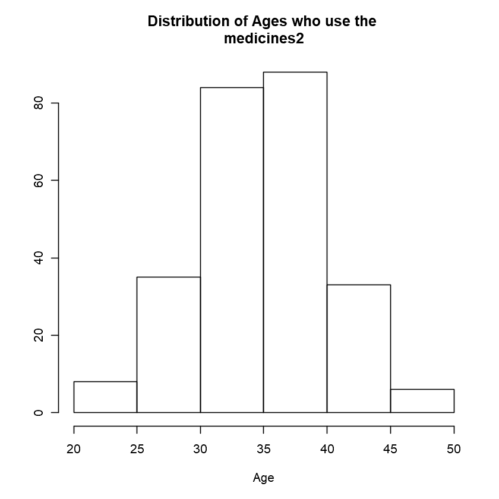

```r
# first, we should determine the breaks (intervals),
# and R will do that for us
breaks1 = hist(df_M2_just$Age,xlab="Age" , ylab="" , main="Distribution of Ages who use the \n medicines2 ")[[1]]
#Frequancy table :
# then assign the suitable interval for each value in the variable "age"
class1 <- cut(df_M2_just $Age, breaks1, right = F)
# then we follow the same steps as before (3rd method)
ff<-data.frame(table(class1))
mutate(ff, relFreq = round(prop.table(Freq),4)*100, cumFreq = cumsum(Freq), cumRelFreq = cumsum(relFreq))
```

A data.frame: 6 × 9

|  | Gender <chr> | Age <int> | KmBefore <dbl> | KgBefore <dbl> | TimeBefore <dbl> | KmAfter <dbl> | KgAfter <dbl> | TimeAfter <dbl> | SideEffects <chr> |
| --- | --- | --- | --- | --- | --- | --- | --- | --- | --- |
| 1 | Male | 32 | 5.12 | 94.1 | 53.6 | 7.07 | 88.2 | 55.5 | No |
| 2 | Male | 35 | 2.17 | 97.8 | 40.7 | 3.59 | 94.3 | 64.1 | No |
| 3 | Male | 43 | 5.21 | 84.5 | 34.1 | 4.88 | 94.3 | 60.0 | No |
| 4 | Male | 42 | 3.55 | 80.6 | 39.5 | 3.36 | 89.3 | 55.7 | No |
| 5 | Male | 42 | 3.66 | 71.5 | 28.3 | 4.30 | 88.0 | 63.5 | Yes |
| 6 | Male | 39 | 4.08 | 79.5 | 38.5 | 4.39 | 89.8 | 58.5 | No |

1. 129

2. 9

A data.frame: 6 × 9

|  | Gender <chr> | Age <int> | KmBefore <dbl> | KgBefore <dbl> | TimeBefore <dbl> | KmAfter <dbl> | KgAfter <dbl> | TimeAfter <dbl> | SideEffects <chr> |
| --- | --- | --- | --- | --- | --- | --- | --- | --- | --- |
| 1 | Female | 44 | 3.93 | 87.6 | 36.8 | 4.30 | 92.4 | 59.2 | No |
| 2 | Female | 31 | 3.73 | 71.8 | 61.2 | 3.79 | 94.8 | 60.5 | No |
| 3 | Female | 34 | 2.96 | 78.9 | 49.3 | 4.85 | 89.4 | 54.1 | No |
| 4 | Female | 35 | 5.65 | 75.4 | 41.4 | 5.07 | 90.9 | 68.5 | No |
| 5 | Female | 34 | 4.56 | 90.9 | 37.6 | 4.89 | 90.7 | 65.6 | No |
| 6 | Female | 33 | 3.89 | 86.2 | 35.9 | 4.78 | 87.7 | 65.1 | No |

1. 125

2. 9

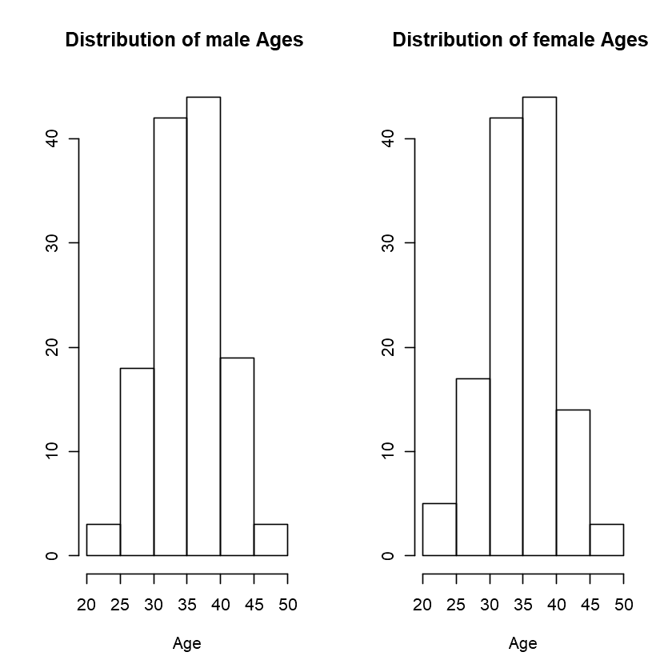

```r
#Distribution of Male/Female Ages who use the medicines2 :
#hist for males and females separately:
par(mfrow=c(1,2))
#male:
df_M2_male<- df_M2_just %>%
  filter( df_M2_just$Gender == "Male")
head(df_M2_male)
dim(df_M2_male)
hist(df_M2_male$Age,xlab="Age", ylab="", main="Distribution of male Ages ")
#female:
df_M2_female<- df_M2_just %>%
  filter( df_M2_just$Gender == "Female")
head(df_M2_female)
dim(df_M2_female)
hist(df_M2_female$Age,xlab="Age", ylab="", main="Distribution of female Ages ")
```

## correlation :

### Is there a relationship between weights ,Running Kilometers and Running time before and after using medicines 2?

1. 254

2. 7

A matrix: 7 × 7 of type dbl

|  | Age | KmBefore | KgBefore | TimeBefore | KmAfter | KgAfter | TimeAfter |
| --- | --- | --- | --- | --- | --- | --- | --- |
| Age | 1.00 | -0.04 | -0.07 | -0.04 | 0.00 | 0.03 | -0.02 |
| KmBefore | -0.04 | 1.00 | 0.07 | 0.01 | -0.02 | 0.05 | -0.03 |
| KgBefore | -0.07 | 0.07 | 1.00 | -0.01 | 0.03 | 0.11 | 0.03 |
| TimeBefore | -0.04 | 0.01 | -0.01 | 1.00 | -0.12 | 0.03 | 0.08 |
| KmAfter | 0.00 | -0.02 | 0.03 | -0.12 | 1.00 | -0.04 | -0.03 |
| KgAfter | 0.03 | 0.05 | 0.11 | 0.03 | -0.04 | 1.00 | -0.01 |
| TimeAfter | -0.02 | -0.03 | 0.03 | 0.08 | -0.03 | -0.01 | 1.00 |

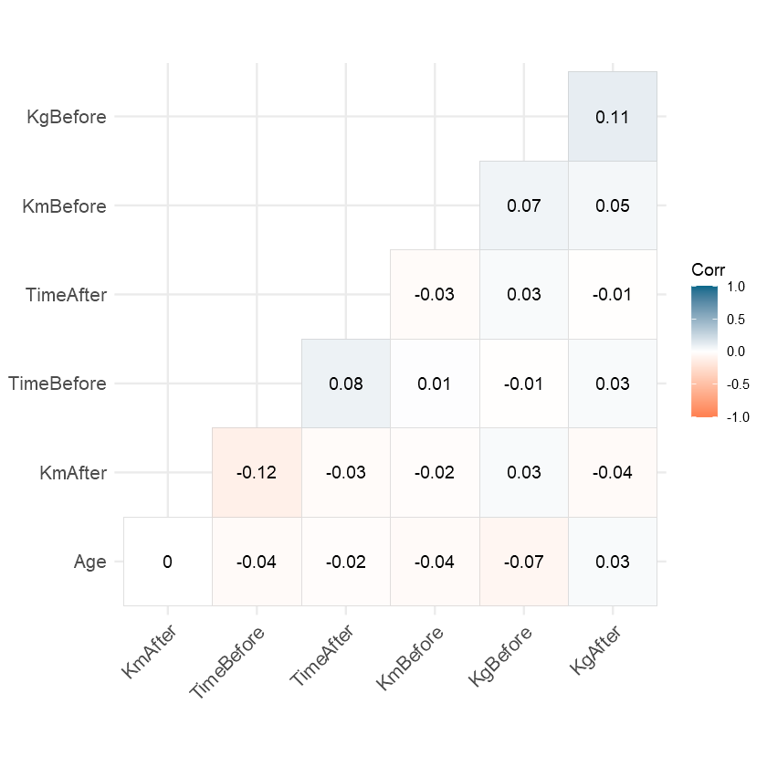

```r
#Is there a relationship between weights ,Running Kilometers and Running time before and after using medicines 2?
df_M2_num<-df_M2_just %>%
  select(-c(Gender,SideEffects))

dim(df_M2_num)

res <- round(cor(df_M2_num) ,2)
res
ggcorrplot(res,
           hc.order = TRUE,
           type = "lower",
           lab = TRUE,
          colors = c("coral", "white", "deepskyblue4"))
```

## Find outlier

1. 1.72

2. 1.85

10.35

1. 55.3

2. 107

3. 54.6

4. 56.1

1. 99.5

2. 97.6

1. 70.6

2. 70.9

43.3

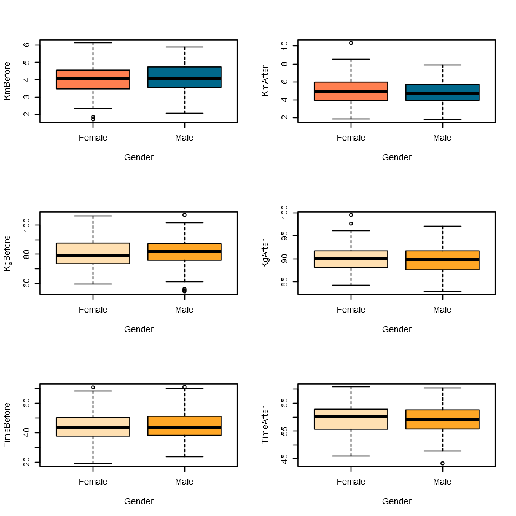

```r
## Create a 3 x 2 plotting matrix
par(mfrow=c(3,2))

#boxplot of kg ,km ,time  by gender :(find outlier )

#boxplot of kg
boxplot( KmBefore~ Gender, data = df_M2_just,col = c("coral", "deepskyblue4"))$out
boxplot( KmAfter~ Gender, data = df_M2_just,col = c("coral", "deepskyblue4"))$out

#boxplot of km
boxplot( KgBefore~ Gender, data = df_M2_just,col = c("#FFE0B2", "#FFA726"))$out
boxplot( KgAfter~ Gender, data = df_M2_just,col = c("#FFE0B2", "#FFA726"))$out

#boxplot of time
boxplot( TimeBefore~ Gender, data = df_M2_just,col = c("#FFE0B2", "#FFA726"))$out
boxplot( TimeAfter~ Gender, data = df_M2_just,col = c("#FFE0B2", "#FFA726"))$out
```

I think the values will not be affected much because they are not far from other values and also because of each person's health and physical condition

## Test: the average of Weight before taking medicine 2 and after

### Assumptions:

The paired samples t-test assume the following characteristics about the data: 1)the two groups are paired. 2)No significant outliers in the difference between the two related groups 3)Normality the difference of pairs follow a normal distribution. (Shapiro-Wilk test, can be used to check the of normality)

```r
#difference:
difference=df_M2_just$KgBefore - df_M2_just$KgAfter
#Shapiro-Wilk test :
shapiro.test(difference)
```

```
	Shapiro-Wilk normality test

data:  difference
W = 0.9971, p-value = 0.928
```

H0: Data follow normal distribution vs. Ha: Data not follow normal distribution p > 0.05, We fail to reject the null hypothesis that our data are normally distributed

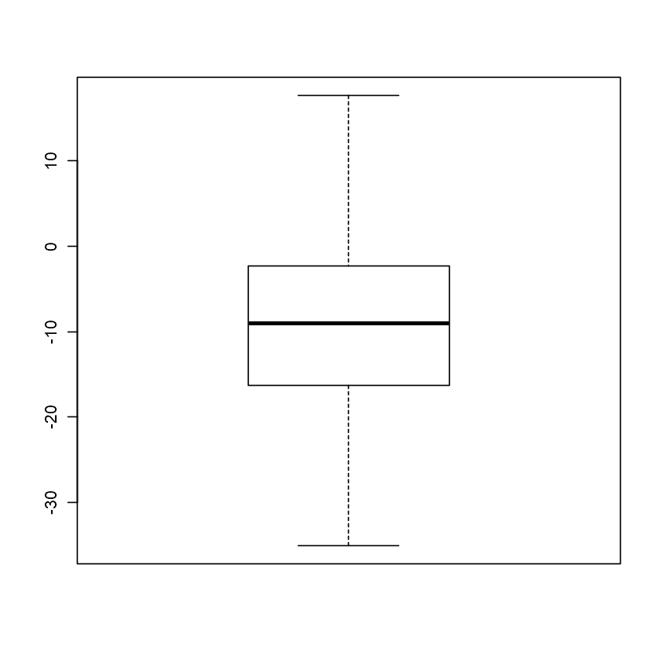

```r
#boxplot:
boxplot(difference)
```

There are no outliers that affect the study

```r
#paired t-test
t.test(df_M2_just$KgBefore,df_M2_just$KgAfter,paired=TRUE)
```

```
	Paired t-test

data:  df_M2_just$KgBefore and df_M2_just$KgAfter
t = -15.327, df = 253, p-value < 2.2e-16
alternative hypothesis: true difference in means is not equal to 0
95 percent confidence interval:
 -10.394581  -8.027466
sample estimates:
mean of the differences
              -9.211024
```

H0: There is no difference in average weight before and after using medicine 2  
vs. Ha: There is difference in average weight before and after using medicine 2 p-value is less than 0.05(significance level) , you can reject the null hypothesis.

```r
mean(df_M2_just$KgBefore)
mean(df_M2_just$KgAfter)
```

80.6893700787402

89.9003937007874

## logistic regression :

```r
#modify values name in the SideEffects column (N to 0 ,Y to 1):
df_M2_just$SideEffects= gsub("Yes", 1 ,df_M2_just$SideEffects)
df_M2_just$SideEffects = gsub("No",0, df_M2_just$SideEffects)
```

```r
head(df_M2_just)
tail(df_M2_just)
```

A data.frame: 6 × 9

|  | Gender <chr> | Age <int> | KmBefore <dbl> | KgBefore <dbl> | TimeBefore <dbl> | KmAfter <dbl> | KgAfter <dbl> | TimeAfter <dbl> | SideEffects <chr> |
| --- | --- | --- | --- | --- | --- | --- | --- | --- | --- |
| 1 | Male | 32 | 5.12 | 94.1 | 53.6 | 7.07 | 88.2 | 55.5 | 0 |
| 2 | Female | 44 | 3.93 | 87.6 | 36.8 | 4.30 | 92.4 | 59.2 | 0 |
| 3 | Female | 31 | 3.73 | 71.8 | 61.2 | 3.79 | 94.8 | 60.5 | 0 |
| 4 | Male | 35 | 2.17 | 97.8 | 40.7 | 3.59 | 94.3 | 64.1 | 0 |
| 5 | Female | 34 | 2.96 | 78.9 | 49.3 | 4.85 | 89.4 | 54.1 | 0 |
| 6 | Male | 43 | 5.21 | 84.5 | 34.1 | 4.88 | 94.3 | 60.0 | 0 |

A data.frame: 6 × 9

|  | Gender <chr> | Age <int> | KmBefore <dbl> | KgBefore <dbl> | TimeBefore <dbl> | KmAfter <dbl> | KgAfter <dbl> | TimeAfter <dbl> | SideEffects <chr> |
| --- | --- | --- | --- | --- | --- | --- | --- | --- | --- |
| 249 | Male | 38 | 4.17 | 75.0 | 45.1 | 4.18 | 92.2 | 56.2 | 0 |
| 250 | Female | 39 | 4.78 | 79.2 | 55.6 | 5.76 | 86.8 | 52.9 | 0 |
| 251 | Male | 40 | 3.75 | 80.2 | 47.7 | 4.11 | 94.0 | 55.1 | 0 |
| 252 | Male | 28 | 5.02 | 97.1 | 48.5 | 4.21 | 86.5 | 60.2 | 0 |
| 253 | Female | 36 | 2.72 | 72.3 | 53.8 | 2.63 | 92.8 | 68.9 | 1 |
| 254 | Male | 32 | 3.92 | 98.7 | 56.2 | 6.31 | 86.0 | 62.3 | 0 |

```r
str(df_M2_just)
```

```
'data.frame':	254 obs. of  9 variables:
 $ Gender     : chr  "Male" "Female" "Female" "Male" ...
 $ Age        : int  32 44 31 35 34 43 42 42 35 34 ...
 $ KmBefore   : num  5.12 3.93 3.73 2.17 2.96 5.21 3.55 3.66 5.65 4.56 ...
 $ KgBefore   : num  94.1 87.6 71.8 97.8 78.9 84.5 80.6 71.5 75.4 90.9 ...
 $ TimeBefore : num  53.6 36.8 61.2 40.7 49.3 34.1 39.5 28.3 41.4 37.6 ...
 $ KmAfter    : num  7.07 4.3 3.79 3.59 4.85 4.88 3.36 4.3 5.07 4.89 ...
 $ KgAfter    : num  88.2 92.4 94.8 94.3 89.4 94.3 89.3 88 90.9 90.7 ...
 $ TimeAfter  : num  55.5 59.2 60.5 64.1 54.1 60 55.7 63.5 68.5 65.6 ...
 $ SideEffects: chr  "0" "0" "0" "0" ...
```

The as.numeric in R is a built-in method that returns a numeric value

```r
df_M2_just$SideEffects <- as.numeric(df_M2_just$SideEffects)
class(df_M2_just$SideEffects)
```

'numeric'

### Do age and gender have a role in the side effects of people who use the Medicine 2?

```r
#Do age and gender have a role in the side effects of people who use the Medicine 2?
model<-glm(SideEffects~Age+Gender ,family = binomial(link = "logit"),data=df_M2_just )
summary(model)
```

```
Call:
glm(formula = SideEffects ~ Age + Gender, family = binomial(link = "logit"),
    data = df_M2_just)

Deviance Residuals:
    Min       1Q   Median       3Q      Max
-0.8881  -0.7367  -0.5214  -0.4530   2.1714

Coefficients:
            Estimate Std. Error z value Pr(>|z|)
(Intercept) -2.28305    1.18161  -1.932  0.05334 .
Age          0.03311    0.03261   1.015  0.30991
GenderMale  -0.93522    0.34517  -2.709  0.00674 **
---
Signif. codes:  0 '***' 0.001 '**' 0.01 '*' 0.05 '.' 0.1 ' ' 1

(Dispersion parameter for binomial family taken to be 1)

    Null deviance: 240.31  on 253  degrees of freedom
Residual deviance: 231.73  on 251  degrees of freedom
AIC: 237.73

Number of Fisher Scoring iterations: 4
```

The model : ln(p/1-p) = -2.28305 + 0.03311 Age -0.93522 GenderMale

As for the gender variable, the male participates in the decrease in exposure to side effects by a value 0.93522 if the patient is male